# DV_RProject1: Titanic

[figure not shown]

## 00. Create/Clone a github repository

Go to SourceTree software. Create new git repository in DataVisualization folder (on same level as DrCannata folder).

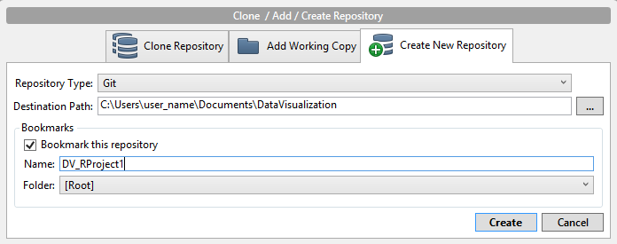

If did not create the repo, clone the repo in SourceTree software.

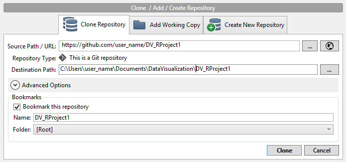

## 01. Create RStudio Project

Create an RStudio project in the project folder.

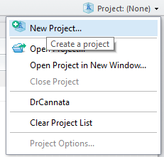

## 02. Setup RStudio

Create three folders in RStudio Project:  
**00 Doc**: where .Rmd lives  
**01 Data**: where data will be stored  
**02 Visualizations**: where data is explored in ggplot

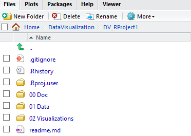

## 03. Build Dataframe

1. Create sqldeveloper worksheet from SQL titanic data.

[figure not shown]

2. Extract data from sqldeveloper to dataframe “df” using SQL:

```r
df <- data.frame(fromJSON(getURL(URLencode('129.152.144.84:5001/rest/native/?query="select * from titanic"'),httpheader=c(DB='jdbc:oracle:thin:@129.152.144.84:1521/PDBF15DV.usuniversi01134.oraclecloud.internal', USER='cs329e_jht585', PASS='orcl_jht585', MODE='native_mode', MODEL='model', returnDimensions = 'False', returnFor = 'JSON'), verbose = TRUE), ))
```

## 04. Display Summary of Dataframe

### Summary of Titanic Dataframe:

```r
summary(df)
```

```
##                                       PASSENGERID  SURVIVED    PCLASS
##  </pre></body></html>Xtext/csvUUTF-8(?N`vPJS:  1   0   :549   1   :216
##  1                                          :  1   1   :342   2   :184
##  10                                         :  1   null:  2   3   :491
##  100                                        :  1              null:  2
##  101                                        :  1
##  102                                        :  1
##  (Other)                                    :887
##                                     NAME         SEX           AGE
##  null                                 :  2   female:314   null   :179
##  Abbing, Mr. Anthony                  :  1   male  :577   24     : 30
##  Abbott, Mr. Rossmore Edward          :  1   null  :  2   22     : 27
##  Abbott, Mrs. Stanton (Rosa Hunt)     :  1                18     : 26
##  Abelson, Mr. Samuel                  :  1                19     : 25
##  Abelson, Mrs. Samuel (Hannah Wizosky):  1                28     : 25
##  (Other)                              :886                (Other):581
##      SIBSP         PARCH          TICKET                  FARE
##  0      :608   0      :678   1601    :  7   8.05000019073486: 43
##  1      :209   1      :118   347082  :  7   13              : 42
##  2      : 28   2      : 80   CA. 2343:  7   7.89580011367798: 38
##  4      : 18   3      :  5   3101295 :  6   7.75            : 34
##  3      : 16   5      :  5   347088  :  6   26              : 31
##  8      :  7   4      :  4   CA 2144 :  6   10.5            : 24
##  (Other):  7   (Other):  3   (Other) :854   (Other)         :681
##          CABIN     EMBARKED
##  null       :689   C   :168
##  B96 B98    :  4   null:  4
##  C23 C25 C27:  4   Q   : 77
##  G6         :  4   S   :644
##  C22 C26    :  3
##  D          :  3
##  (Other)    :186
```

## 05. Display Subset of Dataframe

### Subset of Titanic Dataframe:

- A subset of girls Jack might be interested in on the Titanic.

```r
head(subset(df, PCLASS == 1 & SEX == "female" & as.numeric(as.character(AGE)) > 18))
```

```
##    PASSENGERID SURVIVED PCLASS
## 1          311        1      1
## 9          319        1      1
## 10         320        1      1
## 16         326        1      1
## 28         338        1      1
## 32         342        1      1
##                                                        NAME    SEX AGE
## 1                            Hays, Miss. Margaret Bechstein female  24
## 9                                  Wick, Miss. Mary Natalie female  31
## 10 Spedden, Mrs. Frederic Oakley (Margaretta Corning Stone) female  40
## 16                                 Young, Miss. Marie Grice female  36
## 28                          Burns, Miss. Elizabeth Margaret female  41
## 32                           Fortune, Miss. Alice Elizabeth female  24
##    SIBSP PARCH   TICKET             FARE       CABIN EMBARKED
## 1      0     0    11767 83.1583023071289         C54        C
## 9      0     2    36928  164.86669921875          C7        S
## 10     1     1    16966            134.5         E34        C
## 16     0     0 PC 17760  135.63330078125         C32        C
## 28     0     0    16966            134.5         E40        C
## 32     3     2    19950              263 C23 C25 C27        S
```